# ANÁLISE ECONOMÉTRICA DO IMPACTO DA OFERTA DE ENERGIA ELÉTRICA E PETRÓLEO NA INFLAÇÃO NO BRASIL

[figure not shown]

## Estudo de Séries Temporais (2000-2024)

### Autor: Diego Ribeiro Porto

### MAIO DE 2025

> *"a econometria pode ser definida como a análise quantitativa dos fenômenos econômicos ocorridos com base no desenvolvimento paralelo da teoria e das observações e com o uso de métodos de inferência adequados."*

> — Samuelson, Koopmans, Stone

## ANÁLISE ECONOMÉTRICA DO IMPACTO DA OFERTA DE ENERGIA ELÉTRICA E PETRÓLEO NA INFLAÇÃO NO BRASIL

### 1. Introdução

A inflação é um fenômeno econômico que afeta diretamente o poder de compra da população e a estabilidade econômica de um país. No Brasil, a inflação tem sido uma preocupação constante, com variações significativas ao longo dos anos. Neste contexto, a oferta de energia elétrica e petróleo desempenha um papel crucial na formação dos preços, uma vez que esses insumos são fundamentais para a produção e o consumo de bens e serviços. Neste trabalho, buscamos analisar o impacto da oferta de energia elétrica e petróleo na inflação* no Brasil, utilizando dados mensais de 2000 a 2024. A análise será realizada por meio de modelos econométricos, com o objetivo de identificar a relação entre essas variáveis e a inflação, bem como avaliar a magnitude e a significância desse impacto.

*"A inflação pode ser conceituada como um aumento contínuo e crítico e generalizado no nível de preços. Ous seja, os movimentos inflacionários representam elevações em todos os bens produzidos pela economia e não meramento o aumento de um determinado preço."* (LUQUE, Carlos; VASCONCELLOS, Marco. Considerações sobre o Problema da Inflação. In: PINHO, Diva; VASCONCELLOS, Marco (Orgs.). Manual de economia. 5. ed. São Paulo: Saraiva, 2006. p. 336.)

### 2. Metodologia

A metodologia adotada para a análise do impacto da oferta de energia elétrica armazenada como água nos reservatórios - (`ear`) e da produção de petróleo cru (`oleo_bruto`) sobre a inflação brasileira medida pelo Índice Nacional de Preços ao Consumidor Amplo - (`ipca`) segue uma abordagem baseada em séries temporais mensais no período de 2000 a 2024, estruturada nas seguintes etapas:

A. **Coleta de Dados**  
As séries temporais mensais de `ipca`, `ear` e `oleo_bruto` serão coletadas a partir de fontes oficiais, cobrindo o período de janeiro de 2000 a dezembro de 2024. Os dados foram obtidos no Sistema de Séries Temporais do Banco Central do Brasil (SGS) e no site do Operador Nacional do Sistema Elétrico (ONS).

B. **Análise Gráfica Exploratória**  
As três variáveis serão visualizadas graficamente para identificar padrões de tendência, sazonalidade, possíveis rupturas estruturais e presença de outliers. Serão utilizados histogramas, boxplots, QQ-plots, gráficos de densidade e violinos para apoiar essa caracterização.

C. **Testes de Estacionariedade**  
Serão aplicados testes de estacionariedade, em especial o **Teste de Dickey-Fuller Aumentado (ADF)**, para verificar se as séries possuem média e variância constantes ao longo do tempo. Em caso negativo, serão aplicadas transformações como a **diferenciação**, com o objetivo de torná-las estacionárias, requisito necessário para a modelagem econométrica.

D. **Avaliação de Defasagens e Correlações Temporais**  
A relação temporal entre as variáveis será analisada por meio de **correlação cruzada** (Cross-Correlation Function – CCF), a fim de identificar **defasagens significativas** entre as variáveis explicativas (`ear`, `oleo_bruto`) e a variável explicada (`ipca`).

E. **Modelagem Econométrica com Séries Temporais**  
Serão estimados modelos econométricos apropriados para séries temporais, como:

- **ARIMAX**: quando `ipca` é modelado em função de suas próprias defasagens e variáveis exógenas;

F. **Avaliação do Modelo e Validação Fora da Amostra**  
A qualidade dos modelos será avaliada por meio da análise dos resíduos (autocorrelação, normalidade, homocedasticidade).

G. **Discussão e Conclusões**  
Os resultados obtidos serão interpretados à luz da teoria econômica e da conjuntura brasileira. Serão discutidas as implicações para políticas públicas e sugestões para estudos futuros.

### 3. Análise Descritiva

A análise descritiva das variáveis foi realizada com o objetivo de identificar tendências, sazonalidades e possíveis outliers. A seguir, apresentamos gráficos e estatísticas descritivas das variáveis consideradas na análise.

```python
import pandas as pd
import numpy as np
import seaborn as sns
import statsmodels.api as sm
from statsmodels.graphics.tsaplots import plot_ccf, plot_acf, plot_pacf
import matplotlib.pyplot as plt
from statsmodels.tsa.statespace.sarimax import SARIMAX

# Configurações para melhorar a visualização dos gráficos
plt.style.use('ggplot')
plt.rcParams['figure.figsize'] = (12, 8)
sns.set_palette('Set2')
sns.set_context('talk')
```

```python
df  = pd.read_parquet('dados.parquet')
```

```python
df.head(5)
```

|  | data | ear | u.m_ear | oleo_bruto | u.m_oleo | ipca | u.m_ipca |
| --- | --- | --- | --- | --- | --- | --- | --- |
| 0 | 2000-01-01 | 41.344962 | percentual | 1155 | Barris/dia (mil) | 0.62 | percentual |
| 1 | 2000-02-01 | 52.108976 | percentual | 1121 | Barris/dia (mil) | 0.13 | percentual |
| 2 | 2000-03-01 | 62.794431 | percentual | 1189 | Barris/dia (mil) | 0.22 | percentual |
| 3 | 2000-04-01 | 66.530108 | percentual | 1161 | Barris/dia (mil) | 0.42 | percentual |
| 4 | 2000-05-01 | 61.894345 | percentual | 1159 | Barris/dia (mil) | 0.01 | percentual |

```python
df.tail(5)
```

|  | data | ear | u.m_ear | oleo_bruto | u.m_oleo | ipca | u.m_ipca |
| --- | --- | --- | --- | --- | --- | --- | --- |
| 295 | 2024-08-01 | 61.476806 | percentual | 3340 | Barris/dia (mil) | -0.02 | percentual |
| 296 | 2024-09-01 | 50.736338 | percentual | 3470 | Barris/dia (mil) | 0.44 | percentual |
| 297 | 2024-10-01 | 47.900840 | percentual | 3269 | Barris/dia (mil) | 0.56 | percentual |
| 298 | 2024-11-01 | 48.537575 | percentual | 3310 | Barris/dia (mil) | 0.39 | percentual |
| 299 | 2024-12-01 | 52.692861 | percentual | 3419 | Barris/dia (mil) | 0.52 | percentual |

### Descrição dos Dados

Os dados fornecidos representam séries temporais mensais com as seguintes variáveis:

- `data`: Data de referência.
- `ear`: Energia elétrica armazenada como água nos reservatórios, medida em percentual.
- `u.m_ear`: Unidade de medida da energia elétrica armazenada.
- `oleo_bruto`: Produção de petróleo cru, medida em Barris/dia (mil).
- `u.m_oleo`: Unidade de medida da produção de petróleo.
- `ipca`: Índice Nacional de Preços ao Consumidor Amplo, representando a inflação brasileira, medida em percentual.
- `u.m_ipca`: Unidade de medida do índice de inflação.

```python
# Verificar informações básicas do DataFrame
print("Informações do DataFrame:")
print(f"Shape: {df.shape}")
print("\nInformações das colunas:")
df.info()
```

```
Informações do DataFrame:
Shape: (300, 7)

Informações das colunas:
<class 'pandas.core.frame.DataFrame'>
RangeIndex: 300 entries, 0 to 299
Data columns (total 7 columns):
 #   Column      Non-Null Count  Dtype
---  ------      --------------  -----
 0   data        300 non-null    datetime64[ns]
 1   ear         300 non-null    float64
 2   u.m_ear     300 non-null    object
 3   oleo_bruto  300 non-null    int64
 4   u.m_oleo    300 non-null    object
 5   ipca        300 non-null    float64
 6   u.m_ipca    300 non-null    object
dtypes: datetime64[ns](1), float64(2), int64(1), object(3)
memory usage: 16.5+ KB
```

```python
# Estatísticas descritivas do DataFrame
print("Estatísticas descritivas:")
display(df.describe(exclude=['datetime64[ns]', 'object']).T)
```

```
Estatísticas descritivas:
```

|  | count | mean | std | min | 25% | 50% | 75% | max |
| --- | --- | --- | --- | --- | --- | --- | --- | --- |
| ear | 300.0 | 60.751847 | 13.644838 | 30.028935 | 50.560811 | 60.566563 | 71.783052 | 87.47971 |
| oleo_bruto | 300.0 | 2195.160000 | 631.169277 | 1121.000000 | 1695.000000 | 2077.500000 | 2636.500000 | 3678.00000 |
| ipca | 300.0 | 0.501133 | 0.394905 | -0.680000 | 0.260000 | 0.450000 | 0.675000 | 3.02000 |

```python
# Lista todas as colunas no DataFrame exceto a data (se houver)
numeric_columns = df.select_dtypes(include=['int64', 'float64']).columns.tolist()

# Exibir a lista de variáveis que serão analisadas
print(f"Variáveis numéricas disponíveis para análise: {numeric_columns}")
```

```
Variáveis numéricas disponíveis para análise: ['ear', 'oleo_bruto', 'ipca']
```

```python
def plot_variable_distribution(dataframe, variable):
    """
    Função para criar múltiplos gráficos de distribuição para uma variável
    """
    fig, axes = plt.subplots(2, 2, figsize=(16, 12))
    fig.suptitle(f'Análise de Distribuição: {variable}', fontsize=16)

    # Histograma com curva de densidade
    sns.histplot(dataframe[variable], kde=True, ax=axes[0, 0])
    axes[0, 0].set_title('Histograma com Curva de Densidade')
    axes[0, 0].set_xlabel(variable)
    axes[0, 0].grid(True)

    # Boxplot
    sns.boxplot(y=dataframe[variable], ax=axes[0, 1])
    axes[0, 1].set_title('Boxplot')
    axes[0, 1].set_ylabel(variable)
    axes[0, 1].grid(True)

    # QQ Plot para verificar normalidade
    from scipy import stats
    qq = stats.probplot(dataframe[variable].dropna(), dist="norm", plot=axes[1, 0])
    axes[1, 0].set_title('QQ Plot (Verificação de Normalidade)')
    axes[1, 0].grid(True)

    # Gráfico de violino
    sns.violinplot(y=dataframe[variable], ax=axes[1, 1])
    axes[1, 1].set_title('Violin Plot')
    axes[1, 1].set_ylabel(variable)
    axes[1, 1].grid(True)

    plt.tight_layout(rect=[0, 0, 1, 0.96])
    plt.show()

    # Estatísticas descritivas específicas da variável
    print(f"\nEstatísticas descritivas para {variable}:")
    stats_df = pd.DataFrame({
        'Média': [dataframe[variable].mean()],
        'Mediana': [dataframe[variable].median()],
        'Desvio Padrão': [dataframe[variable].std()],
        'Variância': [dataframe[variable].var()],
        'Mínimo': [dataframe[variable].min()],
        'Máximo': [dataframe[variable].max()],
        'Assimetria': [dataframe[variable].skew()],
        'Curtose': [dataframe[variable].kurtosis()]
    })
    display(stats_df.T)

    # Verificar normalidade com teste estatístico
    print(f"\nTeste de Normalidade (Shapiro-Wilk) para {variable}:")
    shapiro_test = stats.shapiro(dataframe[variable].dropna())
    print(f"Estatística de teste: {shapiro_test[0]:.4f}")
    print(f"Valor p: {shapiro_test[1]:.4f}")
    if shapiro_test[1] < 0.05:
        print("Conclusão: A distribuição não parece ser normal (rejeita hipótese nula).")
    else:
        print("Conclusão: A distribuição pode ser considerada normal (não rejeita hipótese nula).")
```

```
================================================================================
Análise de Distribuição para: ear
================================================================================
```

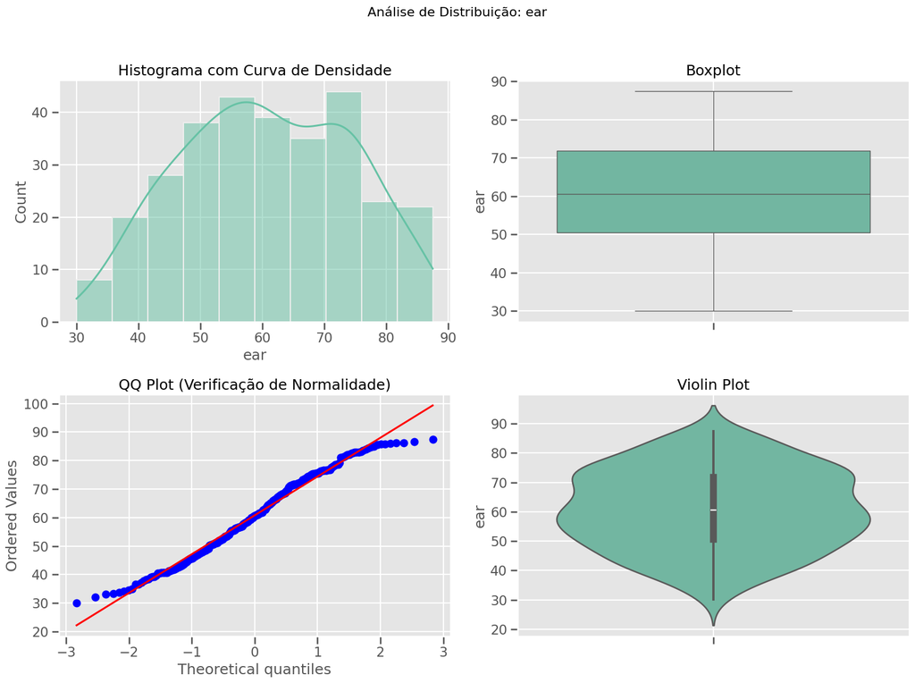

```
Estatísticas descritivas para ear:
```

|  | 0 |
| --- | --- |
| Média | 60.751847 |
| Mediana | 60.566563 |
| Desvio Padrão | 13.644838 |
| Variância | 186.181591 |
| Mínimo | 30.028935 |
| Máximo | 87.479710 |
| Assimetria | -0.039185 |
| Curtose | -0.877915 |

```
Teste de Normalidade (Shapiro-Wilk) para ear:
Estatística de teste: 0.9806
Valor p: 0.0004
Conclusão: A distribuição não parece ser normal (rejeita hipótese nula).

================================================================================
Análise de Distribuição para: oleo_bruto
================================================================================
```

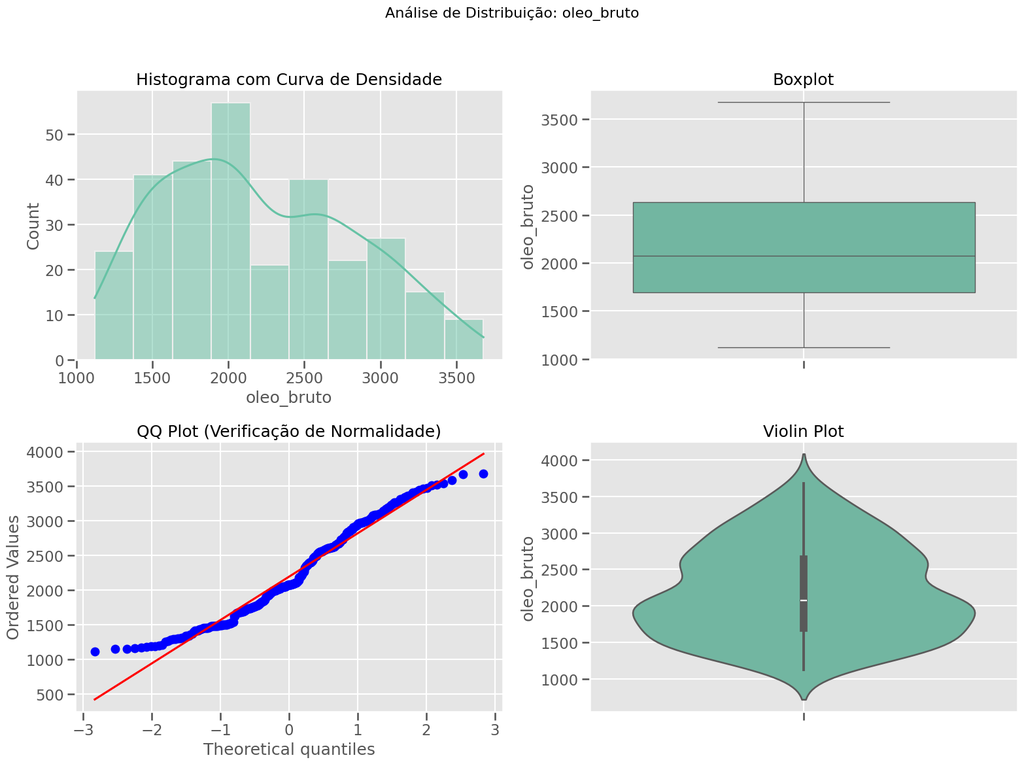

```
Estatísticas descritivas para oleo_bruto:
```

|  | 0 |
| --- | --- |
| Média | 2195.160000 |
| Mediana | 2077.500000 |
| Desvio Padrão | 631.169277 |
| Variância | 398374.656589 |
| Mínimo | 1121.000000 |
| Máximo | 3678.000000 |
| Assimetria | 0.343534 |
| Curtose | -0.850090 |

```
Teste de Normalidade (Shapiro-Wilk) para oleo_bruto:
Estatística de teste: 0.9636
Valor p: 0.0000
Conclusão: A distribuição não parece ser normal (rejeita hipótese nula).

================================================================================
Análise de Distribuição para: ipca
================================================================================
```

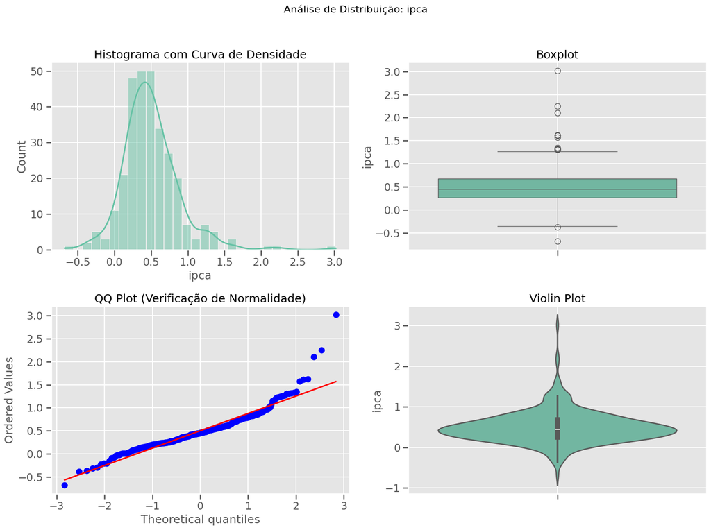

```
Estatísticas descritivas para ipca:
```

|  | 0 |
| --- | --- |
| Média | 0.501133 |
| Mediana | 0.450000 |
| Desvio Padrão | 0.394905 |
| Variância | 0.155950 |
| Mínimo | -0.680000 |
| Máximo | 3.020000 |
| Assimetria | 1.565830 |
| Curtose | 7.158004 |

```
Teste de Normalidade (Shapiro-Wilk) para ipca:
Estatística de teste: 0.9026
Valor p: 0.0000
Conclusão: A distribuição não parece ser normal (rejeita hipótese nula).
```

```python
# Loop para criar gráficos de distribuição para cada variável numérica
for column in numeric_columns:
    print(f"\n{'='*80}")
    print(f"Análise de Distribuição para: {column}")
    print(f"{'='*80}")
    plot_variable_distribution(df, column)
```

## 📊 Tabela Resumo: Estatísticas Descritivas e Teste de Normalidade

### 🔢 Estatísticas Descritivas

[output not shown]

### 🧪 Teste de Normalidade (Shapiro-Wilk)

[output not shown]

### 📊 Descritivo e Análise dos Resultados

##### Curtose

- Indica o grau de achatamento da distribuição em relação a uma distribuição normal.
- O **IPCA** apresenta alta curtose (7.1580), sugerindo presença de muitos valores extremos (distribuição leptocúrtica).
- A **EAR** e o **Óleo Bruto** têm curtoses negativas, indicando distribuições mais achatadas que a normal (platicúrticas).

#### Teste de Normalidade (Shapiro-Wilk)

- Avalia se os dados seguem uma distribuição normal.
- Todos os conjuntos (**IPCA**, **EAR** e **Óleo Bruto**) tiveram **valores-p baixos** (menores que 0.05), levando à rejeição da hipótese de normalidade.
- Isso confirma que as distribuições são **não normais** e podem exigir métodos não paramétricos ou transformações em análises posteriores.

===============================================================================================================================================================================================================================

### 4. Teste de Estacionariedade

Para a modelagem econométrica adequada de séries temporais, é fundamental verificar se as variáveis são estacionárias.

Para isso, vamos primeiro entender o conceito de estacionariedade, vejamos:

*"Em linhas gerais um processo estocástico será chamado de estacionário se sua média e variância forem constantes ao longo do tempo eo valor da covariancia entre os dois períodos de tempo depender apenas da distância, do intervalo ou da defasagem entre os dois periodos e não o tempo real ao qual a covariancia é computada"* (GUJARATI, Damodar; PORTER, Dawn. Econometria básica. 5. ed. Porto Alegre: AMGH, 2009).

Um processo estocástico, por sua vez é: *"Um processo aleatório ou estocástico é uma coleção de variáveis aleatórias ordenadas no tempo"* (GUJARATI, Damodar; PORTER, Dawn. Econometria básica. 5. ed. Porto Alegre: AMGH, 2009).

A estacionariedade implica que a média, variância e autocorrelação da série são constantes ao longo do tempo. Utilizaremos o **Teste de Dickey-Fuller Aumentado (ADF)** para avaliar a estacionariedade das variáveis do nosso estudo: `ipca`, `ear` e `oleo_bruto`.

O teste ADF tem como hipótese nula a presença de raiz unitária (série não estacionária). Se o p-valor for menor que o nível de significância (geralmente 0,05), rejeitamos a hipótese nula e concluímos que a série é estacionária.

Vamos implementar o teste ADF para cada uma das variáveis e interpretar os resultados:

```python
# Implementação do Teste de Dickey-Fuller Aumentado (ADF)
from statsmodels.tsa.stattools import adfuller

def test_adf(series, series_name):
    """
    Função para realizar o teste ADF e interpretar os resultados
    """
    print(f"Teste ADF para {series_name}")
    print("-" * 50)

    # Executar o teste ADF
    result = adfuller(series.dropna())

    # Extrair e apresentar resultados
    adf_statistic = result[0]
    p_value = result[1]
    critical_values = result[4]

    # Exibir resultados
    print(f'Estatística ADF: {adf_statistic:.4f}')
    print(f'Valor p: {p_value:.4f}')
    print('Valores críticos:')
    for key, value in critical_values.items():
        print(f'\t{key}: {value:.4f}')

    # Interpretar resultados
    if p_value < 0.05:
        print(f"Conclusão: Rejeitamos a hipótese nula. ",
              f"A série {series_name} é estacionária (não possui raiz unitária).")
    else:
        print(f"Conclusão: Não rejeitamos a hipótese nula. ",
              f"A série {series_name} não é estacionária (possui raiz unitária).")
    print("\n")
```

```python
# Aplicar o teste ADF para cada variável
# Certifique-se de que o DataFrame está ordenado por data se for uma série temporal
if 'data' in df.columns:
    df = df.sort_values('data')

# Teste para IPCA
test_adf(df['ipca'], 'IPCA')

# Teste para Energia Armazenada (EAR)
test_adf(df['ear'], 'Energia Armazenada (EAR)')

# Teste para Óleo Bruto
test_adf(df['oleo_bruto'], 'Óleo Bruto')
```

```
Teste ADF para IPCA
--------------------------------------------------
Estatística ADF: -8.3602
Valor p: 0.0000
Valores críticos:
	1%: -3.4524
	5%: -2.8713
	10%: -2.5719
Conclusão: Rejeitamos a hipótese nula.  A série IPCA é estacionária (não possui raiz unitária).


Teste ADF para Energia Armazenada (EAR)
--------------------------------------------------
Estatística ADF: -2.5510
Valor p: 0.1036
Valores críticos:
	1%: -3.4533
	5%: -2.8717
	10%: -2.5722
Conclusão: Não rejeitamos a hipótese nula.  A série Energia Armazenada (EAR) não é estacionária (possui raiz unitária).


Teste ADF para Óleo Bruto
--------------------------------------------------
Estatística ADF: -0.4786
Valor p: 0.8961
Valores críticos:
	1%: -3.4526
	5%: -2.8713
	10%: -2.5720
Conclusão: Não rejeitamos a hipótese nula.  A série Óleo Bruto não é estacionária (possui raiz unitária).
```

## 📉 Tabela Resumo: Teste de Estacionariedade (ADF)

| Variável | Estatística ADF | Valor-p | Valores Críticos (1%, 5%, 10%) | Conclusão | Requer Tratamento? |
| --- | --- | --- | --- | --- | --- |
| **IPCA** | -8.3602 | 0.0000 | -3.4524, -2.8713, -2.5719 | ✅ Rejeita H₀ → Série é **estacionária** | Não |
| **Energia Armazenada (EAR)** | -2.5510 | 0.1036 | -3.4533, -2.8717, -2.5722 | ❌ Não rejeita H₀ → Série **não é estacionária** | Sim |
| **Óleo Bruto** | -0.4786 | 0.8961 | -3.4526, -2.8713, -2.5720 | ❌ Não rejeita H₀ → Série **não é estacionária** | Sim |

Como aqui demonstrado, a variável `ipca` é estacionária, enquanto `ear` e `oleo_bruto` não são. Portanto, deve ocorrer o tratamento das variáveis `ear` e `oleo_bruto` para torná-las estacionárias, pois *"Se uma série é não estacionária (...) ela é chamada de série temporal não estacionária (...). Em outras palavras, uma série temporal não estacionária terá uma média que varia com o tempo, ou uma variância que varia com o tempo, ou, ainda, ambas. (...) se uma séria temporal é não estacionária, podemos estudar seu comportamento apenas pelo período em consideração. Cada conjunto de dados de série temporal, portanto, será específico a cada episódio. Como consequência, não é possível generaliza-lo para outros períodos. Sendo assim, para o propósito de previsão, tal séria temporal (não estacionária) pode ser de pouco valor prático"* (GUJARATI, Damodar; PORTER, Dawn. Econometria básica. 5. ed. Porto Alegre: AMGH, 2009).

========================================================================================================================================================================================================

#### .4.1 Análise Visual da Estacionariedade: Gráficos de Séries Temporais

Para complementar a análise formal do teste ADF, vamos visualizar graficamente as séries temporais. Isso nos permitirá observar visualmente se as séries apresentam características de não-estacionariedade, como tendências, mudanças de variância ao longo do tempo ou padrões sazonais persistentes. O que se faz somente para fins ilustrativos, uma vez que o teste ADF já foi realizado e os resultados foram apresentados anteriormente.

```python
# Preparando os dados para visualização de séries temporais
# Verificar se o DataFrame tem uma coluna de data para o índice temporal
if 'data' in df.columns:
    # Converter a coluna de data para índice do DataFrame se ainda não for
    time_series_df = df.set_index('data') if not isinstance(df.index, pd.DatetimeIndex) else df.copy()
else:
    # Se não tiver coluna de data, verificar se o índice já é do tipo datetime
    time_series_df = df.copy()
    if not isinstance(df.index, pd.DatetimeIndex):
        print("Aviso: Não foi encontrada uma coluna de data para criar série temporal")
        # Criar um índice temporal fictício começando de 01/01/2000 com frequência mensal
        time_series_df.index = pd.date_range(start='2000-01-01', periods=len(df), freq='M')

# Função para plotar séries temporais com análise de estacionariedade
def plot_time_series_stationarity(dataframe, column_name):
    """
    Função para criar gráficos de série temporal com análise de estacionariedade
    - Gráfico da série original
    - Média móvel
    - Desvio padrão móvel
    """
    plt.figure(figsize=(14, 10))

    # Criar uma figura com 3 subplots verticalmente empilhados
    fig, (ax1, ax2, ax3) = plt.subplots(3, 1, figsize=(14, 12), sharex=True)

    # Plot 1: Série temporal original
    series = dataframe[column_name].dropna()
    ax1.plot(series.index, series.values, label='Série Original')
    ax1.set_title(f'Série Temporal: {column_name}', fontsize=14)
    ax1.set_ylabel('Valor')
    ax1.legend(loc='upper left', fontsize=8, framealpha=0.7)
    ax1.grid(True)

    # Plot 2: Média Móvel (janela de 12 meses e 24 meses)
    rolling_mean_12 = series.rolling(window=12).mean()
    rolling_mean_24 = series.rolling(window=24).mean()
    ax2.plot(series.index, series.values, label='Série Original', alpha=0.5, color='gray')
    ax2.plot(rolling_mean_12.index, rolling_mean_12.values, label='Média Móvel (12 meses)', color='red')
    ax2.plot(rolling_mean_24.index, rolling_mean_24.values, label='Média Móvel (24 meses)', color='green')
    ax2.set_title(f'Análise de Tendência (Média Móvel): {column_name}', fontsize=14)
    ax2.set_ylabel('Valor')
    ax2.legend(loc='upper left', fontsize=8, framealpha=0.7, ncol=2)
    ax2.grid(True)

    # Plot 3: Desvio Padrão Móvel (janela de 12 meses)
    rolling_std_12 = series.rolling(window=12).std()
    rolling_std_24 = series.rolling(window=24).std()
    ax3.plot(rolling_std_12.index, rolling_std_12.values, label='Desvio Padrão Móvel (12 meses)', color='purple')
    ax3.plot(rolling_std_24.index, rolling_std_24.values, label='Desvio Padrão Móvel (24 meses)', color='orange')
    ax3.set_title(f'Análise de Variância (Desvio Padrão Móvel): {column_name}', fontsize=14)
    ax3.set_xlabel('Data')
    ax3.set_ylabel('Desvio Padrão')
    ax3.legend(loc='upper left', fontsize=8, framealpha=0.7, ncol=2)
    ax3.grid(True)

    plt.tight_layout()
    plt.show()

    # Estatísticas básicas da série
    media = series.mean()
    mediana = series.median()
    desvio_padrao = series.std()

    print(f"\nEstatísticas básicas para {column_name}:")
    print("-" * 50)
    print(f"Média: {media:.4f}")
    print(f"Mediana: {mediana:.4f}")
    print(f"Desvio Padrão: {desvio_padrao:.4f}")
    print("-" * 50)

    # Avaliação da estacionariedade com base nos gráficos
    print(f"\nAnálise visual de estacionariedade para {column_name}:")
    print("-" * 70)

    # Analisar a presença de tendência (média móvel)
    if rolling_mean_12.max() - rolling_mean_12.min() > 0.1 * series.mean():
        print("Tendência: A série parece apresentar tendência (média não constante ao longo do tempo)")
        print(f"  Variação na média móvel: {rolling_mean_12.max() - rolling_mean_12.min():.4f}")
    else:
        print("Tendência: A série não apresenta tendência significativa (média relativamente constante)")

    # Analisar a estabilidade da variância (desvio padrão móvel)
    if rolling_std_12.max() / (rolling_std_12.min() + 1e-10) > 1.5:  # Evita divisão por zero
        print("Variância: A série parece apresentar heterocedasticidade (variância não constante)")
        print(f"  Razão máx/mín do desvio padrão: {rolling_std_12.max() / (rolling_std_12.min() + 1e-10):.4f}")
    else:
        print("Variância: A série parece ter variância relativamente constante (homocedasticidade)")

    # Conclusão preliminar
    if (rolling_mean_12.max() - rolling_mean_12.min() > 0.1 * series.mean()) or (rolling_std_12.max() / (rolling_std_12.min() + 1e-10) > 1.5):
        print("\nConclusão preliminar: A série apresenta características de não-estacionariedade")
    else:
        print("\nConclusão preliminar: A série apresenta características de estacionariedade")
    print("-" * 70)
```

```
================================================================================
Análise de Série Temporal para: ipca
================================================================================
```

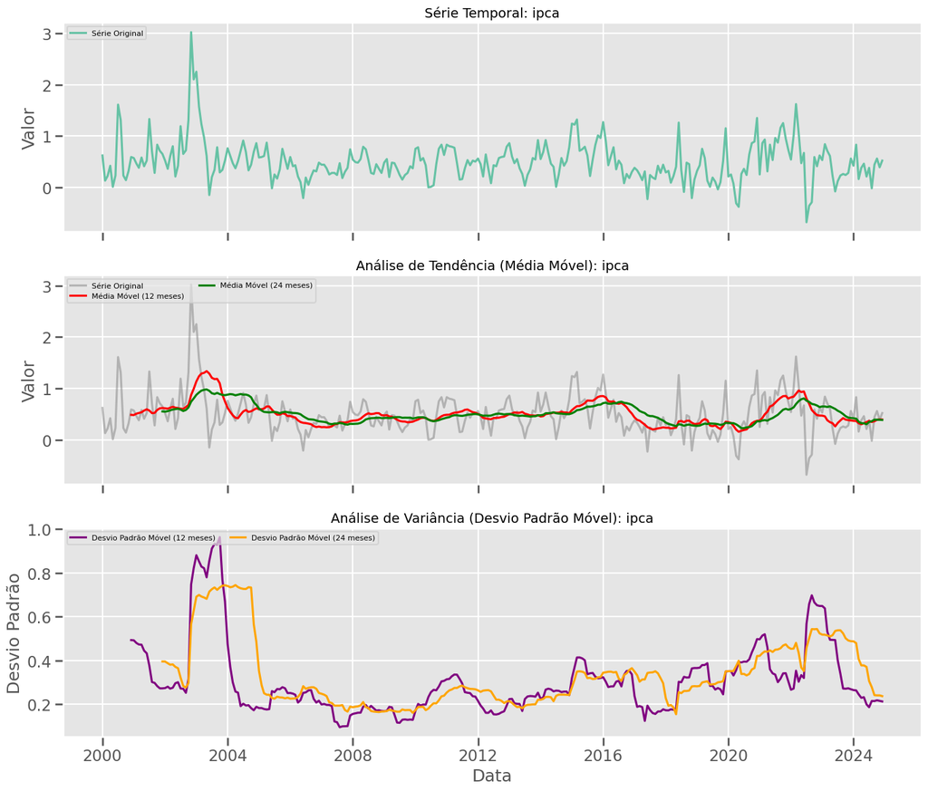

```
Estatísticas básicas para ipca:
--------------------------------------------------
Média: 0.5011
Mediana: 0.4500
Desvio Padrão: 0.3949
--------------------------------------------------

Análise visual de estacionariedade para ipca:
----------------------------------------------------------------------
Tendência: A série parece apresentar tendência (média não constante ao longo do tempo)
  Variação na média móvel: 1.1808
Variância: A série parece apresentar heterocedasticidade (variância não constante)
  Razão máx/mín do desvio padrão: 10.0771

Conclusão preliminar: A série apresenta características de não-estacionariedade
----------------------------------------------------------------------

================================================================================
Análise de Série Temporal para: ear
================================================================================
```

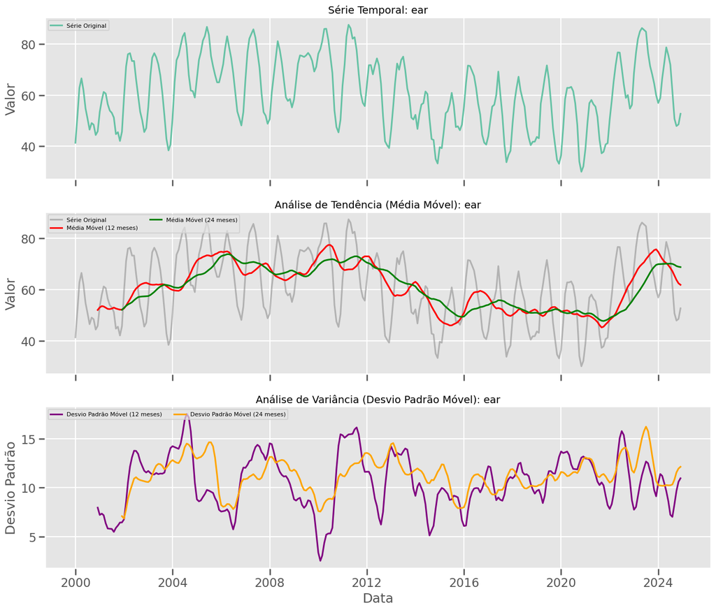

```
Estatísticas básicas para ear:
--------------------------------------------------
Média: 60.7518
Mediana: 60.5666
Desvio Padrão: 13.6448
--------------------------------------------------

Análise visual de estacionariedade para ear:
----------------------------------------------------------------------
Tendência: A série parece apresentar tendência (média não constante ao longo do tempo)
  Variação na média móvel: 32.2463
Variância: A série parece apresentar heterocedasticidade (variância não constante)
  Razão máx/mín do desvio padrão: 7.0249

Conclusão preliminar: A série apresenta características de não-estacionariedade
----------------------------------------------------------------------

================================================================================
Análise de Série Temporal para: oleo_bruto
================================================================================
```

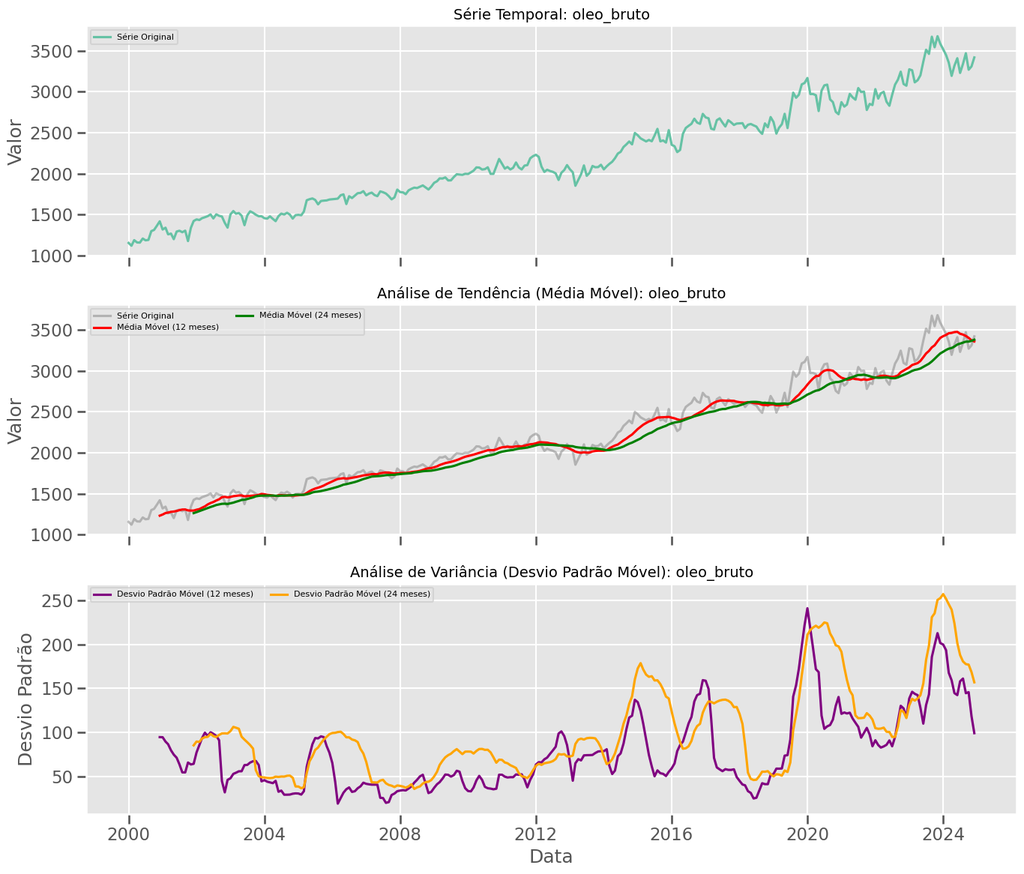

```
Estatísticas básicas para oleo_bruto:
--------------------------------------------------
Média: 2195.1600
Mediana: 2077.5000
Desvio Padrão: 631.1693
--------------------------------------------------

Análise visual de estacionariedade para oleo_bruto:
----------------------------------------------------------------------
Tendência: A série parece apresentar tendência (média não constante ao longo do tempo)
  Variação na média móvel: 2243.8333
Variância: A série parece apresentar heterocedasticidade (variância não constante)
  Razão máx/mín do desvio padrão: 12.5054

Conclusão preliminar: A série apresenta características de não-estacionariedade
----------------------------------------------------------------------
```

```python
# Aplicar a análise de série temporal para cada variável
variables_to_analyze = ['ipca', 'ear', 'oleo_bruto']

for var in variables_to_analyze:
    print(f"\n{'=' * 80}")
    print(f"Análise de Série Temporal para: {var}")
    print(f"{'=' * 80}")
    plot_time_series_stationarity(time_series_df, var)
```

#### 📉 Tabela Resumo Final – Estacionariedade (Teste ADF + Análise Visual)

| Variável | Tendência Aparente | Heterocedasticidade (Razão máx/mín) | Estatística ADF | Valor-p | Conclusão ADF | Conclusão Visual | Requer Tratamento? |
| --- | --- | --- | --- | --- | --- | --- | --- |
| **IPCA** | Sim (variação média: 1.18) | Sim (10.08) | -8.3602 | 0.0000 | ✅ Série estacionária | ❌ Não estacionária visualmente | **Não** |
| **EAR** | Sim (variação média: 32.25) | Sim (7.02) | -2.5510 | 0.1036 | ❌ Série não estacionária | ❌ Não estacionária visualmente | **Sim** |
| **Óleo Bruto** | Sim (variação média: 2243.83) | Sim (12.51) | -0.4786 | 0.8961 | ❌ Série não estacionária | ❌ Não estacionária visualmente | **Sim** |

==================================================================================================================================================================================================================================================================

#### .4.2 Tratamento de Variáveis

Nesta seção, realizaremos o tratamento das variáveis que apresentaram características de não-estacionariedade ou outros problemas identificados nas análises anteriores. O objetivo é preparar as séries temporais para a modelagem econométrica, garantindo que atendam aos requisitos necessários, como estacionariedade e estabilidade de variância.

As transformações recomendadas serão aplicadas conforme a tabela resumo apresentada anteriormente. Após o tratamento, as séries serão reavaliadas para confirmar a eficácia das transformações realizadas.

## 🔧 Tabela Resumo: Transformações Recomendadas para Estacionariedade

| Variável | Transformação Recomendada | Objetivo Principal | Justificativa Técnica |
| --- | --- | --- | --- |
| **IPCA** | Nenhuma | Já é estacionária | O teste ADF rejeitou a hipótese de raiz unitária; série pode ser usada no formato atual |
| **EAR** | 1ª diferença (`x_t - x_(t-1)`) | Remover tendência e estabilizar a média | Série apresenta tendência e leve heterocedasticidade; valores percentuais não exigem log |
| **Óleo Bruto** | Log-diferença (`log(x_t) - log(x_(t-1))`) | Reduzir escala e estabilizar variância | Série tem escala alta e variância crescente; transformação ajuda a lidar com isso e permite interpretação percentual |

```python
# Aplicando as transformações recomendadas para alcançar estacionariedade
# Criando uma cópia do DataFrame para não modificar o original
df_transformed = df.copy()

# 1. Aplicando a primeira diferença (x_t - x_{t-1}) na variável EAR
df_transformed['ear_diff'] = df_transformed['ear'].diff()

# 2. Aplicando a log-diferença (log(x_t) - log(x_{t-1})) na variável Óleo Bruto
df_transformed['oleo_bruto_log_diff'] = np.log(df_transformed['oleo_bruto']).diff()

# Removendo as primeiras linhas que terão valores NaN devido à diferenciação
df_transformed = df_transformed.dropna(subset=['ear_diff', 'oleo_bruto_log_diff'])

# Visualizando as primeiras linhas do DataFrame transformado
print("Primeiras linhas do DataFrame com as variáveis transformadas:")
display(df_transformed[['ipca', 'ear', 'ear_diff', 'oleo_bruto', 'oleo_bruto_log_diff']].head())

# Visualizando estatísticas descritivas das variáveis transformadas
print("\nEstatísticas descritivas das variáveis transformadas:")
display(df_transformed[['ear_diff', 'oleo_bruto_log_diff']].describe().T)
```

```
Primeiras linhas do DataFrame com as variáveis transformadas:
```

|  | ipca | ear | ear_diff | oleo_bruto | oleo_bruto_log_diff |
| --- | --- | --- | --- | --- | --- |
| 1 | 0.13 | 52.108976 | 10.764014 | 1121 | -0.029879 |
| 2 | 0.22 | 62.794431 | 10.685455 | 1189 | 0.058891 |
| 3 | 0.42 | 66.530108 | 3.735677 | 1161 | -0.023831 |
| 4 | 0.01 | 61.894345 | -4.635762 | 1159 | -0.001724 |
| 5 | 0.23 | 54.794167 | -7.100179 | 1209 | 0.042236 |

```
Estatísticas descritivas das variáveis transformadas:
```

|  | count | mean | std | min | 25% | 50% | 75% | max |
| --- | --- | --- | --- | --- | --- | --- | --- | --- |
| ear_diff | 299.0 | 0.037953 | 5.903282 | -14.593406 | -4.305174 | -0.20190 | 4.569417 | 14.046825 |
| oleo_bruto_log_diff | 299.0 | 0.003630 | 0.033736 | -0.102385 | -0.014679 | 0.00292 | 0.021242 | 0.128105 |

```python
# Realizando o teste ADF nas variáveis transformadas
print("\n" + "="*80)
print("TESTES DE ESTACIONARIEDADE NAS SÉRIES TRANSFORMADAS")
print("="*80)

# Teste para EAR diferenciada
test_adf(df_transformed['ear_diff'], 'Energia Armazenada (EAR) - Primeira Diferença')

# Teste para Óleo Bruto com log-diferença
test_adf(df_transformed['oleo_bruto_log_diff'], 'Óleo Bruto - Log-Diferença')
```

```
================================================================================
TESTES DE ESTACIONARIEDADE NAS SÉRIES TRANSFORMADAS
================================================================================
Teste ADF para Energia Armazenada (EAR) - Primeira Diferença
--------------------------------------------------
Estatística ADF: -5.7136
Valor p: 0.0000
Valores críticos:
	1%: -3.4533
	5%: -2.8717
	10%: -2.5722
Conclusão: Rejeitamos a hipótese nula.  A série Energia Armazenada (EAR) - Primeira Diferença é estacionária (não possui raiz unitária).


Teste ADF para Óleo Bruto - Log-Diferença
--------------------------------------------------
Estatística ADF: -11.1966
Valor p: 0.0000
Valores críticos:
	1%: -3.4527
	5%: -2.8714
	10%: -2.5720
Conclusão: Rejeitamos a hipótese nula.  A série Óleo Bruto - Log-Diferença é estacionária (não possui raiz unitária).
```

```
================================================================================
ANÁLISE VISUAL DE ESTACIONARIEDADE - SÉRIES TRANSFORMADAS
================================================================================

================================================================================
Análise de Série Temporal para: EAR - Primeira Diferença
================================================================================
```

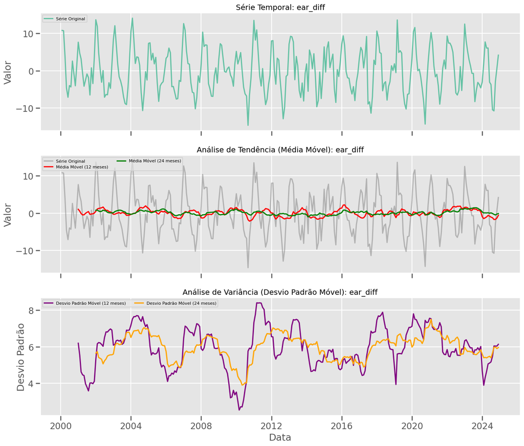

```
Estatísticas básicas para ear_diff:
--------------------------------------------------
Média: 0.0380
Mediana: -0.2019
Desvio Padrão: 5.9033
--------------------------------------------------

Análise visual de estacionariedade para ear_diff:
----------------------------------------------------------------------
Tendência: A série parece apresentar tendência (média não constante ao longo do tempo)
  Variação na média móvel: 4.3491
Variância: A série parece apresentar heterocedasticidade (variância não constante)
  Razão máx/mín do desvio padrão: 3.3183

Conclusão preliminar: A série apresenta características de não-estacionariedade
----------------------------------------------------------------------

================================================================================
Análise de Série Temporal para: Óleo Bruto - Log-Diferença
================================================================================
```

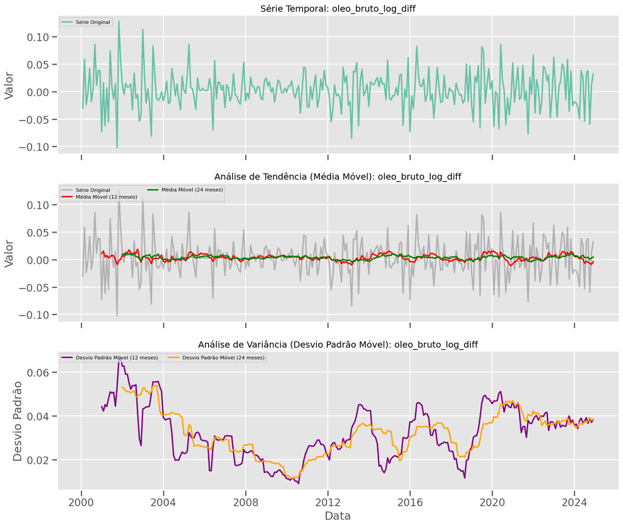

```
Estatísticas básicas para oleo_bruto_log_diff:
--------------------------------------------------
Média: 0.0036
Mediana: 0.0029
Desvio Padrão: 0.0337
--------------------------------------------------

Análise visual de estacionariedade para oleo_bruto_log_diff:
----------------------------------------------------------------------
Tendência: A série parece apresentar tendência (média não constante ao longo do tempo)
  Variação na média móvel: 0.0298
Variância: A série parece apresentar heterocedasticidade (variância não constante)
  Razão máx/mín do desvio padrão: 7.5026

Conclusão preliminar: A série apresenta características de não-estacionariedade
----------------------------------------------------------------------
```

```python
# Análise visual de estacionariedade para as variáveis transformadas
# Criando um DataFrame de séries temporais com as variáveis transformadas
time_series_transformed_df = df_transformed.copy()
if 'data' in time_series_transformed_df.columns:
    time_series_transformed_df = time_series_transformed_df.set_index('data')

# Aplicar a análise visual para cada variável transformada
print("\n" + "="*80)
print("ANÁLISE VISUAL DE ESTACIONARIEDADE - SÉRIES TRANSFORMADAS")
print("="*80)

# Análise para EAR diferenciada
print("\n" + "="*80)
print("Análise de Série Temporal para: EAR - Primeira Diferença")
print("="*80)
plot_time_series_stationarity(time_series_transformed_df, 'ear_diff')

# Análise para Óleo Bruto com log-diferença
print("\n" + "="*80)
print("Análise de Série Temporal para: Óleo Bruto - Log-Diferença")
print("="*80)
plot_time_series_stationarity(time_series_transformed_df, 'oleo_bruto_log_diff')
```

### 📉 Tabela Resumo – Estacionariedade das Séries Transformadas (Visual + ADF)

O teste ADF tem como hipótese nula a presença de raiz unitária (série não estacionária). Se o p-valor for menor que o nível de significância (geralmente 0,05), rejeitamos a hipótese nula e concluímos que a série é estacionária.

| Variável Transformada | Transformação Aplicada | Estatística ADF | Valor-p | Conclusão ADF | Variação na Média Móvel | Razão Máx/Mín do Desvio Padrão | Conclusão Visual |
| --- | --- | --- | --- | --- | --- | --- | --- |
| **EAR (Energia Armazenada)** | 1ª diferença (`x_t - x_(t-1)`) | -5.7136 | 0.0000 | ✅ Série estacionária | 4.3491 | 3.3183 | ❌ Aparência de não-estacionária |
| **Óleo Bruto** | Log-diferença (`log(x_t) - log(x_(t-1))`) | -11.1966 | 0.0000 | ✅ Série estacionária | 0.0298 | 7.5026 | ❌ Aparência de não-estacionária |

### 5. Análise de Correlação entre IPCA, EAR_Diff e Óleo Bruto (Log-Diferença)

Nesta seção, realizaremos uma análise de correlação entre as variáveis transformadas `ear_diff` (diferença da energia armazenada), `oleo_bruto_log_diff` (log-diferença da produção de óleo bruto) e o índice de preços ao consumidor amplo (`ipca`).

O objetivo é identificar a força e a direção das relações lineares entre essas variáveis, fornecendo insights iniciais sobre possíveis interdependências que podem ser exploradas em modelagens econométricas futuras. Utilizaremos métricas como o coeficiente de correlação de Pearson e visualizações gráficas para apoiar a análise.

##### Análise de Correlação Cruzada (CCF) entre IPCA e Variáveis Transformadas

A correlação cruzada (Cross-Correlation Function - CCF) é uma técnica estatística que mede a relação entre duas séries temporais em diferentes defasagens. Esta análise nos permite identificar se mudanças em uma variável precedem, coincidem ou seguem mudanças em outra variável, e com qual intensidade ocorre essa relação.

Abaixo, visualizaremos os gráficos de CCF entre o IPCA e as variáveis transformadas (ear_diff e oleo_bruto_log_diff), além de apresentarmos uma tabela com os valores específicos das correlações em diferentes defasagens.

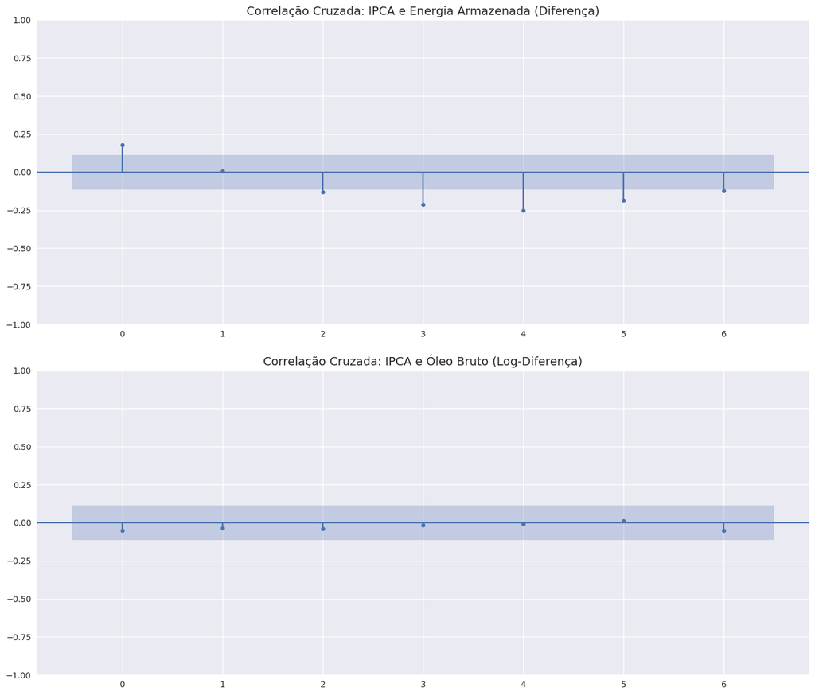

```python
# Análise de Correlação Cruzada (CCF) usando statsmodels.graphics.tsaplots

# Configuração para melhorar a visualização
plt.style.use('seaborn-v0_8')
plt.rcParams['figure.figsize'] = (14, 10)

# Definindo o número máximo de lags para análise
lags = 6

# Criando uma figura com 2 subplots para CCF
fig, axes = plt.subplots(2, 1, figsize=(14, 12))

# Gráfico CCF entre IPCA e EAR (diferença)
plot_ccf(df_transformed['ipca'], df_transformed['ear_diff'], lags=lags, ax=axes[0])
axes[0].set_title('Correlação Cruzada: IPCA e Energia Armazenada (Diferença)', fontsize=14)
axes[0].grid(True)

# Gráfico CCF entre IPCA e Óleo Bruto (log-diferença)
plot_ccf(df_transformed['ipca'], df_transformed['oleo_bruto_log_diff'], lags=lags, ax=axes[1])
axes[1].set_title('Correlação Cruzada: IPCA e Óleo Bruto (Log-Diferença)', fontsize=14)
axes[1].grid(True)

plt.tight_layout()
plt.show()
```

```
Correlações entre IPCA e variáveis transformadas com defasagens:
```

|  | Lag (meses) | Corr(ipca, oleo_bruto_lag) | Corr(ipca, ear_lag) |
| --- | --- | --- | --- |
| 0 | 0 | -0.05 | 0.18 |
| 1 | 1 | -0.04 | 0.01 |
| 2 | 2 | -0.04 | -0.13 |
| 3 | 3 | -0.02 | -0.21 |
| 4 | 4 | -0.01 | -0.25 |
| 5 | 5 | 0.01 | -0.19 |
| 6 | 6 | -0.05 | -0.13 |

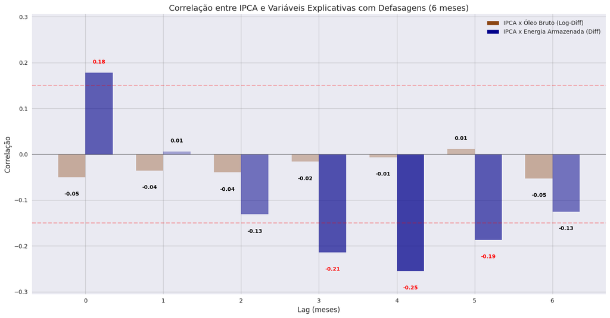

```python
# Calculando as correlações entre IPCA e as variáveis transformadas com diferentes defasagens (lags)
max_lag = 6
lag_data = {'Lag (meses)': list(range(max_lag + 1))}

# Criando variáveis com defasagens para Óleo Bruto (log-diferença)
oil_lag_corr = []
for lag in range(max_lag + 1):
    # Criando a série defasada
    oil_lagged = df_transformed['oleo_bruto_log_diff'].shift(lag)
    # Calculando a correlação e armazenando
    corr = df_transformed['ipca'].corr(oil_lagged)
    oil_lag_corr.append(corr)

# Criando variáveis com defasagens para Energia Armazenada (diferença)
ear_lag_corr = []
for lag in range(max_lag + 1):
    # Criando a série defasada
    ear_lagged = df_transformed['ear_diff'].shift(lag)
    # Calculando a correlação e armazenando
    corr = df_transformed['ipca'].corr(ear_lagged)
    ear_lag_corr.append(corr)

# Criando o DataFrame com os resultados das correlações
lag_data['Corr(ipca, oleo_bruto_lag)'] = oil_lag_corr
lag_data['Corr(ipca, ear_lag)'] = ear_lag_corr

lag_df = pd.DataFrame(lag_data)

# Exibindo a tabela formatada
print("Correlações entre IPCA e variáveis transformadas com defasagens:")
display(lag_df.style.format({
    'Corr(ipca, oleo_bruto_lag)': '{:.2f}',
    'Corr(ipca, ear_lag)': '{:.2f}'
}))

# Visualização gráfica das correlações
plt.figure(figsize=(15, 8))
width = 0.35
x = np.arange(len(lag_df['Lag (meses)']))

# Definindo cores base para as barras
oil_color = '#8B4513'  # Marrom escuro para óleo
ear_color = '#00008B'  # Azul escuro para energia

# Plotando barras individualmente para poder ajustar a transparência de cada uma
for i, (oil_val, ear_val) in enumerate(zip(lag_df['Corr(ipca, oleo_bruto_lag)'], lag_df['Corr(ipca, ear_lag)'])):
    # Calculando opacidade baseada na força da correlação
    oil_alpha = min(0.3 + abs(oil_val)*1.7, 1.0)
    ear_alpha = min(0.3 + abs(ear_val)*1.7, 1.0)

    # Plotando barras individuais
    plt.bar(i - width/2, oil_val, width, color=oil_color, alpha=oil_alpha)
    plt.bar(i + width/2, ear_val, width, color=ear_color, alpha=ear_alpha)

    # Adicionando texto nas barras
    text_color_oil = 'red' if abs(oil_val) > 0.15 else 'black'
    text_color_ear = 'red' if abs(ear_val) > 0.15 else 'black'

    y_offset_oil = 0.02 if oil_val >= 0 else -0.04
    y_offset_ear = 0.02 if ear_val >= 0 else -0.04

    plt.text(i - width/2, oil_val + y_offset_oil, f'{oil_val:.2f}',
             ha='center', fontsize=9, fontweight='bold', color=text_color_oil)

    plt.text(i + width/2, ear_val + y_offset_ear, f'{ear_val:.2f}',
             ha='center', fontsize=9, fontweight='bold', color=text_color_ear)

# Adicionando legendas manualmente para evitar múltiplas entradas
import matplotlib.patches as mpatches
oil_patch = mpatches.Patch(color=oil_color, label='IPCA x Óleo Bruto (Log-Diff)')
ear_patch = mpatches.Patch(color=ear_color, label='IPCA x Energia Armazenada (Diff)')
plt.legend(handles=[oil_patch, ear_patch], loc='best')

plt.xlabel('Lag (meses)', fontsize=12)
plt.ylabel('Correlação', fontsize=12)
plt.title(f'Correlação entre IPCA e Variáveis Explicativas com Defasagens ({max_lag} meses)', fontsize=14)
plt.xticks(x, lag_df['Lag (meses)'])
plt.axhline(y=0, color='black', linestyle='-', alpha=0.3)
plt.grid(True, alpha=0.3, color='gray')

# Destacando o limite de significância estatística (exemplo)
plt.axhline(y=0.15, color='red', linestyle='--', alpha=0.3, label='Limite de significância')
plt.axhline(y=-0.15, color='red', linestyle='--', alpha=0.3)

# Ajustando os limites do eixo y para melhor visualização
y_max = max(max(abs(val) for val in oil_lag_corr), max(abs(val) for val in ear_lag_corr))
plt.ylim(-y_max*1.2, y_max*1.2)
plt.tight_layout()
plt.show()
```

### Tabela de Correlações entre IPCA e Variáveis com Defasagens

A tabela abaixo apresenta os valores da correlação entre o IPCA e as variáveis explicativas (Óleo Bruto e Energia Armazenada) em diferentes defasagens temporais (lags). Valores positivos indicam uma relação direta, enquanto valores negativos indicam uma relação inversa. Quanto mais próximo de 1 ou -1, mais forte é a correlação.

#### 🔁 Tabela Resumo – Correlação Cruzada entre IPCA e Variáveis Explicativas (Transformadas)

[output not shown]

## 6. Introdução ao Modelo ARIMAX para Nossa Análise

O modelo ARIMAX (AutoRegressive Integrated Moving Average with eXogenous variables) é uma extensão do modelo ARIMA que incorpora variáveis exógenas ou independentes na modelagem de séries temporais. Enquanto o ARIMA modela uma série temporal baseando-se apenas em seus valores passados e erros de previsão, o ARIMAX permite que fatores externos também influenciem nas previsões.

### Definição e Estrutura do Modelo ARIMAX para Análise da Inflação

Aplicando o modelo ARIMAX ao nosso caso específico, modelaremos o `ipca` como função de suas próprias defasagens e das variáveis explicativas `ear_diff` (diferença da energia armazenada) e `oleo_bruto_log_diff` (log-diferença da produção de óleo bruto):

$$IPCA_t = c + \phi_1 IPCA_{t-1} + \phi_2 IPCA_{t-2} + ... + \phi_p IPCA_{t-p} + \beta_1 EAR\_DIFF_t + \beta_2 EAR\_DIFF_{t-3} + \beta_3 EAR\_DIFF_{t-4} + \beta_4 EAR\_DIFF_{t-5} + \beta_5 OLEO\_DIFF_t + \epsilon_t + \theta_1 \epsilon_{t-1} + \theta_2 \epsilon_{t-2} + ... + \theta_q \epsilon_{t-q}$$

Onde:

- $IPCA_t$ é o índice de preços ao consumidor no período t
- $\phi_i$ são os parâmetros autoregressivos do IPCA
- $\beta_j$ são os coeficientes das variáveis exógenas
- $EAR\_DIFF_t$ é a diferença na energia armazenada no período t
- $OLEO\_DIFF_t$ é a log-diferença na produção de óleo bruto no período t
- $\epsilon_t$ é o termo de erro
- $\theta_i$ são os parâmetros de médias móveis

### Determinação dos Parâmetros p, d, q para Nossa Análise

**1. Parâmetro d (Integração):**

Para as três variáveis em nossa análise, já realizamos testes de estacionariedade e transformações:

- **IPCA**: O teste ADF (p-valor < 0.0001) demonstrou que esta série já é estacionária em seu formato original, portanto, d = 0.
- **Energia Armazenada**: Aplicamos a primeira diferença para torná-la estacionária (`ear_diff`), que o teste ADF confirmou (p-valor < 0.0001), portanto d = 0 para a série transformada.
- **Óleo Bruto**: Aplicamos a log-diferença para torná-la estacionária (`oleo_bruto_log_diff`), que o teste ADF confirmou (p-valor < 0.0001), portanto d = 0 para a série transformada.

**2. Parâmetro p (Autoregressivo) para o IPCA:**

Para determinar o valor adequado de p para o modelo, precisamos:

- **Análise da PACF do IPCA**: Devemos examinar a Função de Autocorrelação Parcial para identificar até qual defasagem há correlação significativa do IPCA com seus valores passados.
- **Testes com diferentes valores**: Estimaremos modelos com diferentes valores de p e selecionaremos com base nos critérios AIC ou BIC.

**3. Incorporação das Defasagens das Variáveis Exógenas:**

Conforme observado na análise de correlação cruzada:

- **Energia Armazenada (`ear_diff`)**: Identificamos correlações negativas moderadas nos lags 3, 4 e 5. Isto sugere que a redução da energia armazenada tende a preceder aumentos na inflação com 3 a 5 meses de defasagem. Para capturar adequadamente este efeito, nosso modelo incluirá as variáveis `ear_diff_t-3`, `ear_diff_t-4` e `ear_diff_t-5` como preditores.
- **Óleo Bruto (`oleo_bruto_log_diff`)**: Não identificamos correlação expressiva em nenhuma defasagem analisada. Entretanto, por completude, manteremos a variável contemporânea no modelo, com a possibilidade de removê-la caso não apresente significância estatística.

**4. Parâmetro q (Médias Móveis):**

- **Análise da ACF**: Examinaremos a Função de Autocorrelação dos resíduos para identificar padrões de média móvel.
- **Comparação de modelos**: Assim como para p, testaremos diferentes valores de q e selecionaremos o modelo com melhor desempenho.

A abordagem final consistirá em estimar diferentes especificações do modelo ARIMAX(p,0,q) para o IPCA, incorporando as variáveis exógenas nas defasagens identificadas, e selecionar aquele com melhor ajuste e capacidade preditiva conforme os critérios estatísticos.

#### 6.1. Análise da Função de Autocorrelação Parcial (PACF) para IPCA

Para determinar o valor adequado do parâmetro 'p' (componente autoregressivo) no modelo ARIMAX, precisamos analisar a Função de Autocorrelação Parcial (PACF) da variável dependente IPCA. A PACF nos mostra a correlação entre a série e suas próprias defasagens, eliminando os efeitos das defasagens intermediárias.

Em termos práticos, as defasagens (lags) com valores significativos na PACF sugerem a quantidade de termos autoregressivos que devem ser incluídos no modelo. Ao identificar até qual defasagem existem correlações parciais significativas (acima das linhas tracejadas que representam o intervalo de confiança), determinamos o valor apropriado de 'p' para o modelo ARIMAX.

A seguir, implementaremos o cálculo e visualização da PACF para a variável IPCA, bem como a Função de Autocorrelação (ACF) para auxiliar na determinação do parâmetro 'q' (componente de médias móveis).

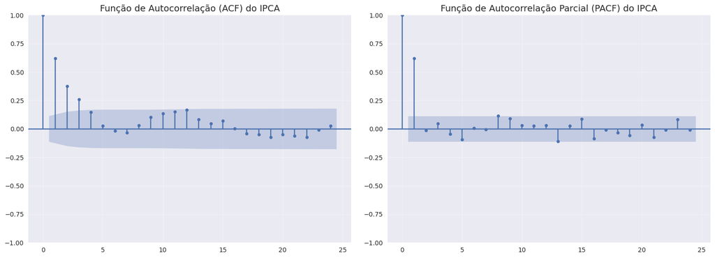

```python
# Configuração para melhorar a visualização
plt.figure(figsize=(16, 8))

# Criando subplots para ACF e PACF
fig, (ax1, ax2) = plt.subplots(1, 2, figsize=(16, 6))

# Plotando a Função de Autocorrelação (ACF) - ajuda a identificar o parâmetro q
plot_acf(df_transformed['ipca'], lags=24, ax=ax1, alpha=0.05)
ax1.set_title('Função de Autocorrelação (ACF) do IPCA', fontsize=14)
ax1.grid(True, alpha=0.3)

# Plotando a Função de Autocorrelação Parcial (PACF) - ajuda a identificar o parâmetro p
plot_pacf(df_transformed['ipca'], lags=24, ax=ax2, alpha=0.05)
ax2.set_title('Função de Autocorrelação Parcial (PACF) do IPCA', fontsize=14)
ax2.grid(True, alpha=0.3)

plt.tight_layout()
plt.show()
```

#### 6.2 Criação das Variáveis do Modelo Final

Abaixo, selecionamos diretamente apenas as variáveis mais relevantes para nossa análise: IPCA, defasagens 3, 4 e 5 da diferença da energia armazenada (`ear_diff`) e a log-diferença do óleo bruto. Esta seleção segue o princípio da parcimônia, buscando um modelo equilibrado entre complexidade e poder explicativo, além de reduzir riscos de multicolinearidade.

```python
# Criando as defasagens relevantes da variável ear_diff diretamente
df_transformed['ear_diff_lag3'] = df_transformed['ear_diff'].shift(3)
df_transformed['ear_diff_lag4'] = df_transformed['ear_diff'].shift(4)
df_transformed['ear_diff_lag5'] = df_transformed['ear_diff'].shift(5)

# Selecionando apenas as variáveis relevantes para o modelo final
vars_model = ['data', 'ipca', 'ear_diff_lag3', 'ear_diff_lag4', 'ear_diff_lag5', 'oleo_bruto_log_diff']
df_model = df_transformed[vars_model].dropna()

# Examinando os dados resultantes
print("DataFrame para modelagem com variáveis selecionadas:")
display(df_model.head())
display(df_model.tail())
```

```
DataFrame para modelagem com variáveis selecionadas:
```

|  | data | ipca | ear_diff_lag3 | ear_diff_lag4 | ear_diff_lag5 | oleo_bruto_log_diff |
| --- | --- | --- | --- | --- | --- | --- |
| 6 | 2000-07-01 | 1.61 | 3.735677 | 10.685455 | 10.764014 | -0.018364 |
| 7 | 2000-08-01 | 1.31 | -4.635762 | 3.735677 | 10.685455 | 0.004203 |
| 8 | 2000-09-01 | 0.23 | -7.100179 | -4.635762 | 3.735677 | 0.085962 |
| 9 | 2000-10-01 | 0.14 | -3.965457 | -7.100179 | -4.635762 | 0.011481 |
| 10 | 2000-11-01 | 0.32 | -4.341973 | -3.965457 | -7.100179 | 0.038811 |

|  | data | ipca | ear_diff_lag3 | ear_diff_lag4 | ear_diff_lag5 | oleo_bruto_log_diff |
| --- | --- | --- | --- | --- | --- | --- |
| 295 | 2024-08-01 | -0.02 | 6.061808 | 6.039319 | 7.690167 | 0.033489 |
| 296 | 2024-09-01 | 0.44 | -3.049863 | 6.061808 | 6.039319 | 0.038184 |
| 297 | 2024-10-01 | 0.56 | -3.700372 | -3.049863 | 6.061808 | -0.059670 |
| 298 | 2024-11-01 | 0.39 | -10.432112 | -3.700372 | -3.049863 | 0.012464 |
| 299 | 2024-12-01 | 0.52 | -10.740468 | -10.432112 | -3.700372 | 0.032400 |

### 6.3 Modelagem SARIMAX

Agora que temos nosso DataFrame `df_model` com as variáveis selecionadas, vamos aplicar o modelo SARIMAX (Seasonal AutoRegressive Integrated Moving Average with eXogenous variables) para analisar o impacto das variáveis explícativas sobre o IPCA.

Como variáveis explícativas (exogênas), utilizaremos:

- Defasagens da energia armazenada: `ear_diff_lag3`, `ear_diff_lag4`, `ear_diff_lag5`
- Log-diferença do óleo bruto: `oleo_bruto_log_diff`

```python
# Garantindo que a coluna 'data' é datetime
df_model['data'] = pd.to_datetime(df_model['data'])

# Definindo 'data' como índice
df_model = df_model.set_index('data')

# Ajustando explicitamente a frequência para 'MS' (início do mês)
df_model = df_model.asfreq('MS')
```

```python
# Separando os últimos 2 anos para teste (2023-01-01 em diante)
train = df_model.loc[:'2022-12-01']
test = df_model.loc['2023-01-01':]

# Separando variáveis dependente e exógenas
y_train = train['ipca']
X_train = train[['ear_diff_lag3', 'ear_diff_lag4', 'ear_diff_lag5', 'oleo_bruto_log_diff']]

y_test = test['ipca']
X_test = test[['ear_diff_lag3', 'ear_diff_lag4', 'ear_diff_lag5', 'oleo_bruto_log_diff']]
```

```python
# Ajustando o modelo ARIMAX(2,0,0)
model = SARIMAX(
    y_train,
    exog=X_train,
    order=(2, 0, 0),
    enforce_stationarity=False,
    enforce_invertibility=False
)

results = model.fit()

# Exibindo o resumo dos resultados
print(results.summary())
```

```
                               SARIMAX Results
==============================================================================
Dep. Variable:                   ipca   No. Observations:                  270
Model:               SARIMAX(2, 0, 0)   Log Likelihood                 -75.985
Date:                Thu, 05 Jun 2025   AIC                            165.970
Time:                        19:35:25   BIC                            191.106
Sample:                    07-01-2000   HQIC                           176.066
                         - 12-01-2022
Covariance Type:                  opg
=======================================================================================
                          coef    std err          z      P>|z|      [0.025      0.975]
---------------------------------------------------------------------------------------
ear_diff_lag3          -0.0026      0.005     -0.547      0.584      -0.012       0.007
ear_diff_lag4          -0.0115      0.005     -2.373      0.018      -0.021      -0.002
ear_diff_lag5          -0.0008      0.005     -0.176      0.860      -0.010       0.008
oleo_bruto_log_diff     0.0539      0.442      0.122      0.903      -0.813       0.921
ar.L1                   0.7463      0.053     13.993      0.000       0.642       0.851
ar.L2                   0.1246      0.058      2.138      0.033       0.010       0.239
sigma2                  0.1032      0.006     15.943      0.000       0.091       0.116
===================================================================================
Ljung-Box (L1) (Q):                   1.22   Jarque-Bera (JB):               306.32
Prob(Q):                              0.27   Prob(JB):                         0.00
Heteroskedasticity (H):               1.12   Skew:                             0.26
Prob(H) (two-sided):                  0.60   Kurtosis:                         8.21
===================================================================================

Warnings:
[1] Covariance matrix calculated using the outer product of gradients (complex-step).
```

### ✅ Resumo do Ajuste ARIMAX(2,0,0)

[output not shown]

### ✅ **Conclusões gerais:**

- O modelo confirma **forte dependência temporal** do IPCA — AR(1) e AR(2) **estatisticamente significativos**.
- Entre as variáveis exógenas, apenas **`ear_diff_lag4`** mantém-se **significativa**:  
  ➡️ Redução na Energia Armazenada impacta o IPCA com 4 meses de defasagem, consistente com hipóteses econômicas.
- As demais variáveis exógenas (`lag3`, `lag5`, `óleo_bruto_log_diff`) são **não significativas** e poderiam ser **removidas** para simplificação do modelo.
- O modelo apresenta **bons resíduos**:  
  ✅ **Sem autocorrelação** (Ljung-Box).  
  ✅ **Sem heterocedasticidade**.  
  ❌ **Mas não normalidade** — presença de **caudas pesadas** ou **outliers**.
- **Critérios AIC/BIC** indicam ajuste razoável — servem como base para **comparação com modelos mais simples**.

#### 6.4 Simplificação do Modelo ARIMAX

Com base na análise dos resultados do modelo inicial, verificamos que algumas variáveis exógenas não apresentaram significância estatística. Para obter um modelo mais parcimonioso, vamos simplificar o modelo removendo as variáveis não significativas:

- **Variáveis não significativas removidas**:
  - `ear_diff_lag3` (p-valor = 0.584)
  - `ear_diff_lag5` (p-valor = 0.860)
  - `oleo_bruto_log_diff` (p-valor = 0.903)
- **Variáveis mantidas**:
  - Componente autoregressivo AR(1) (p-valor < 0.001)
  - Componente autoregressivo AR(2) (p-valor = 0.033)
  - `ear_diff_lag4` (p-valor = 0.018)

Essa simplificação segue o princípio da parcimônia, que favorece modelos mais simples quando apresentam poder explicativo equivalente. Um modelo mais simples é geralmente mais robusto, menos propenso a overfitting e mais fácil de interpretar.

```python
# Realizando previsão para o conjunto de teste
forecast = results.get_forecast(steps=len(y_test), exog=X_test)

# Obtendo previsões médias
predicted_mean = forecast.predicted_mean
```

```python
# Implementação do modelo ARIMAX simplificado
# Agora usando apenas a variável exógena significativa: ear_diff_lag4

# Separando as variáveis para o modelo simplificado
X_train_simplified = train[['ear_diff_lag4']]
X_test_simplified = test[['ear_diff_lag4']]

# Ajustando o modelo ARIMAX(2,0,0) simplificado
model_simplified = SARIMAX(
    y_train,
    exog=X_train_simplified,
    order=(2, 0, 0),
    enforce_stationarity=False,
    enforce_invertibility=False
)

results_simplified = model_simplified.fit()

# Exibindo o resumo dos resultados do modelo simplificado
print(results_simplified.summary())
```

```
                               SARIMAX Results
==============================================================================
Dep. Variable:                   ipca   No. Observations:                  270
Model:               SARIMAX(2, 0, 0)   Log Likelihood                 -76.194
Date:                Thu, 05 Jun 2025   AIC                            160.387
Time:                        19:35:25   BIC                            174.751
Sample:                    07-01-2000   HQIC                           166.156
                         - 12-01-2022
Covariance Type:                  opg
=================================================================================
                    coef    std err          z      P>|z|      [0.025      0.975]
---------------------------------------------------------------------------------
ear_diff_lag4    -0.0121      0.004     -2.737      0.006      -0.021      -0.003
ar.L1             0.7497      0.053     14.145      0.000       0.646       0.854
ar.L2             0.1212      0.059      2.068      0.039       0.006       0.236
sigma2            0.1034      0.005     19.107      0.000       0.093       0.114
===================================================================================
Ljung-Box (L1) (Q):                   1.16   Jarque-Bera (JB):               290.07
Prob(Q):                              0.28   Prob(JB):                         0.00
Heteroskedasticity (H):               1.12   Skew:                             0.27
Prob(H) (two-sided):                  0.58   Kurtosis:                         8.07
===================================================================================

Warnings:
[1] Covariance matrix calculated using the outer product of gradients (complex-step).
```

### ✅ Resumo do Ajuste ARIMAX(2,0,0) — Modelo Simplificado

[output not shown]

### ✅ **Conclusões gerais:**

- O modelo simplificado **manteve a qualidade** do ajuste, com redução dos critérios **AIC/BIC**, indicando um modelo mais **parcimonioso** e **eficiente**.
- A variável exógena **`ear_diff_lag4`** permaneceu **significativa**, confirmando sua **relevância econômica**:  
  ➡️ Queda na disponibilidade hídrica precede **elevação** do IPCA após **4 meses**.
- O IPCA continua a apresentar uma **forte componente autoregressiva** — dependência clara com os dois últimos valores.
- O modelo apresentou **bons resíduos**:  
  ✅ **Sem autocorrelação** (Ljung-Box).  
  ✅ **Sem heterocedasticidade**.  
  ❌ **Mas com não normalidade** — resíduos com **caudas pesadas**.
- Modelo **adequado** para previsão e análise, especialmente pela sua **simplicidade e eficiência**.

### ✅ Exame Gráfico — Previsão ARIMAX(2,0,0)

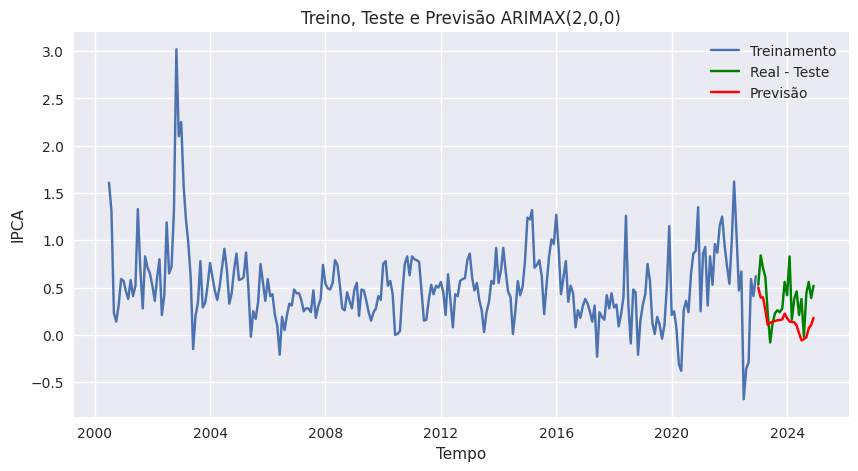

```python
import matplotlib.pyplot as plt

plt.figure(figsize=(10, 5))

# Série real do treinamento
plt.plot(y_train.index, y_train, label='Treinamento')

# Série real do teste
plt.plot(y_test.index, y_test, label='Real - Teste', color='green')

# Série prevista
plt.plot(y_test.index, predicted_mean, label='Previsão', color='red')

plt.xlabel('Tempo')
plt.ylabel('IPCA')
plt.title('Treino, Teste e Previsão ARIMAX(2,0,0)')
plt.legend()
plt.grid(True)
plt.show()
```

##### ✅ **Descrição do Gráfico:**

- **Linha azul**: série histórica do **IPCA** no conjunto de **treinamento** (2000 até 2022).
- **Linha verde**: valores **reais** do IPCA no conjunto de **teste**.
- **Linha vermelha**: **previsões** do modelo ARIMAX(2,0,0) para o mesmo período de teste.

##### ✅ **Considerações importantes:**

- A presença de **não normalidade** nos resíduos (identificada no resumo do modelo) pode explicar eventuais **desvios** ou **erros** maiores em pontos específicos.
- As variáveis exógenas incluídas não contribuíram significativamente, exceto **`ear_diff_lag4`**, que pode estar ajudando a **ajustar a tendência**.
- A **forte componente autoregressiva** (AR(1) e AR(2)) foi crucial para a qualidade da previsão.

### ✅ Exemplos de Cálculo Manual — Cenários Extremos de `ear_diff_lag4`

#### ➡️ **Equação com parâmetros estimados:**

[ \begin{aligned} \text{IPCA}_t =\ & 0.7497 \cdot \text{IPCA}_{t-1} \\ & +\ 0.1212 \cdot \text{IPCA}_{t-2} \\ & -\ 0.0121 \cdot \text{ear\_diff\_lag4}_t \\ & +\ \epsilon_t \end{aligned} ]

⚠️ Para previsão pontual, assumimos (\epsilon_t = 0).

## ✅ **Exemplo 1 — Cenário extremo: forte queda na EAR**

| Variável | Valor |
| --- | --- |
| **IPCA<sub>t-1</sub>** | 0.50 |
| **IPCA<sub>t-2</sub>** | 0.45 |
| **ear_diff_lag4<sub>t</sub>** | -5.00 |

**Aplicando a equação:**

[ \begin{aligned} \text{IPCA}_t =\ & 0.7497 \times 0.50 \\ & +\ 0.1212 \times 0.45 \\ & -\ 0.0121 \times (-5.00) \\ & +\ 0 \end{aligned} ]

**Resolvendo:**

[ \begin{aligned} \text{IPCA}_t &= 0.37485 + 0.05454 + 0.0605 \\ &= 0.48989 \end{aligned} ]

✅ **Previsão do IPCA<sub>t</sub>:** **≈ 0.490**

## ✅ **Exemplo 2 — Cenário extremo: forte aumento na EAR**

| Variável | Valor |
| --- | --- |
| **IPCA<sub>t-1</sub>** | 0.50 |
| **IPCA<sub>t-2</sub>** | 0.45 |
| **ear_diff_lag4<sub>t</sub>** | 5.00 |

**Aplicando a equação:**

[ \begin{aligned} \text{IPCA}_t =\ & 0.7497 \times 0.50 \\ & +\ 0.1212 \times 0.45 \\ & -\ 0.0121 \times 5.00 \\ & +\ 0 \end{aligned} ]

**Resolvendo:**

[ \begin{aligned} \text{IPCA}_t &= 0.37485 + 0.05454 - 0.0605 \\ &= 0.36889 \end{aligned} ]

✅ **Previsão do IPCA<sub>t</sub>:** **≈ 0.369**

### ✅ **Interpretação dos exemplos:**

- Quando ocorre uma **forte queda** na **energia armazenada** (`ear_diff_lag4 = -5.00`), o modelo prevê um **aumento** no IPCA (≈ **0.490**).
- Quando há um **forte aumento** na **energia armazenada** (`ear_diff_lag4 = 5.00`), o modelo prevê uma **redução** no IPCA (≈ **0.369**).
- Isso confirma que o modelo capta um **efeito negativo** entre a variação da **energia armazenada** e a **inflação**:  
  ➡️ **Menos água** → **mais inflação**.  
  ➡️ **Mais água** → **menos inflação**.

⚠️ Lembre-se:  
→ Estes cálculos são **previsões determinísticas** (não consideram o **termo aleatório**).  
→ Para incluir **incerteza**, deve-se usar os **intervalos de confiança** baseados na variância residual.

### ✅ **Resumo interpretativo:**

- O modelo simplificado mantém a estrutura essencial da relação: o IPCA depende **fortemente** de seus **valores passados** e da **disponibilidade hídrica defasada** em 4 meses.
- A remoção das variáveis não significativas (**ear_diff_lag3**, **ear_diff_lag5** e **óleo_bruto_log_diff**) resultou em um modelo mais **parcimonioso** e com **melhores critérios de ajuste**.
- O modelo confirma a hipótese de que **reduções na energia armazenada** representam um fator relevante para a **inflação brasileira**, com um efeito **defasado de aproximadamente 4 meses**.

### 7. Conclusões da Análise

#### Implicações para Políticas Públicas

- **Planejamento energético**: Os resultados sugerem que o planejamento adequado de recursos hídricos e capacidade de armazenamento energético pode ter impactos positivos no controle inflacionário de médio prazo.
- **Previsibilidade**: O lag temporal de 4 meses oferece uma janela de previsibilidade que pode ser utilizada por formuladores de políticas monetárias e fiscais para ajustes preventivos.

#### Limitações e Pesquisas Futuras

- **Variáveis omitidas**: Outras variáveis não contempladas neste estudo, como política monetária, câmbio e fatores climáticos, podem ter influência significativa na relação estudada.
- **Extensões possíveis**: Análises futuras poderiam incorporar efeitos não-lineares, interações entre variáveis ou modelos com mudança de regime para capturar possíveis assimetrias na relação entre energia e inflação.